# Checkpoint 2 - report

Authors:

- Michał Kucharczyk
- Edward Sucharda

Repository: https://github.com/quczer/DALEX

## 1. Topic

The goal of this project is to extend Dalex[^1](https://github.com/ModelOriented/DALEX) by Regression Shap[^2](https://github.com/iancovert/shapley-regression).

## 2. Work

We forked Dalex repository and implemented new class called Unbiased Kernel Shap which is expected to calculate estimated Shapley Values at it was in the paper[^2](https://github.com/iancovert/shapley-regression). We wrote unit tests for this class and its method and successfuly installed library via pip. Our experiments were performed on Titanic[^3](https://www.kaggle.com/c/titanic) dataset. We have trained three different binary classification models to compare results: Random Forrest, Support Vector Machine and Logistic Regression. Tests checked influence of different number of samples on performace. We compared results with regular Kernel Shap method form library shap[^4](https://github.com/slundberg/shap/blob/master/docs/index.rst). We calculated errors from both methods compering to exact shapley values. The results are presented in the next paragraph.

## 3. Results

The method plot created charts exactly in the same standard as it is implemeneted in Dalex.

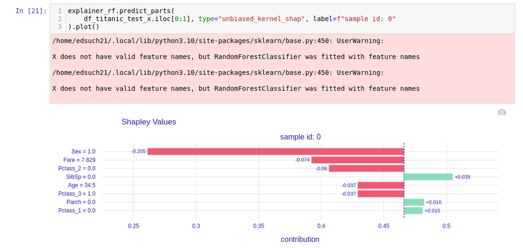

Implemetned class properly calculated values which were close to original shapley values. Experimets showed that results are worse in comparison to regular Kernel Shap. On the first chart below the error is a mean absolute error over whole test set and the second chart shows mean absolute realtive error.

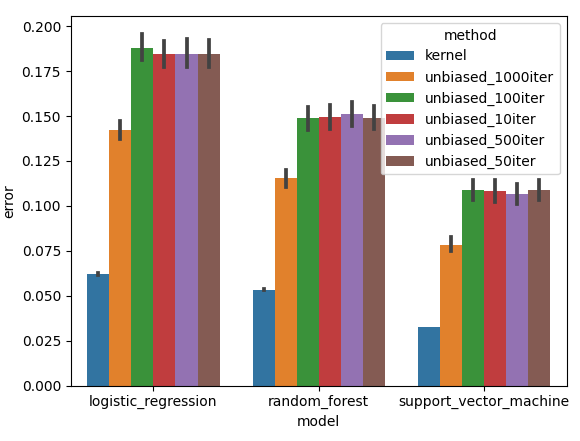

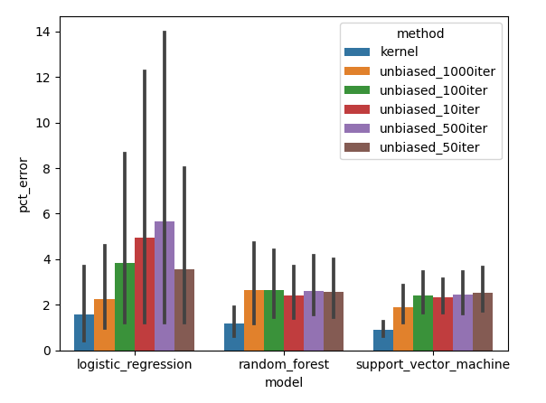

## 4. Summary

We succeeded in extending Dalex with required method. We need to add threshold parameter in created class so number of samples will be calculated automaticly ensuring level of convergence. Moreover more statistical test would should be performed.